[figure not shown]

# Welcome to the showcase!

You can navigate through the slides with `Space` or `Arrow` keys (←, ↑, →, ↓).  
You get an overview with `Esc`.  
draf stands for demand response analysis framework.

[figure not shown]

## Model formulation

- `params_func`: Model parameters are defined with (meta)data. Variables are defined through bounds, type, and metadata.
- `model_func`: Sets the model constraints depending on the model (m), dimensions (d), parameters (p), and variables (v).
- `postprocess_func`: Ensures non-negative timeseries, that are easier to handle for sankey plots and logarithm-based plots.
- `sankey_func`: At the moment energy flows have to be specified manually for later use in sankey plots.

It is best practice to import these long functions from a seperate file e.g. `from case_studies.showcase import *` to share a model formulation with different jupyter-notebooks.

This model is a very gereral model for distributed energy resources including Battery Energy System (BES), Battery Electric Vehicle (BEV), Combined Heat and Power (CHP), Heat Pumps (HP), Photovoltaic (PV), etc. First we only use the BES.

```python
import draf
```

```python
def model_func(m, d, p, v):
    T = d.T
    m.setObjective(((1 - p.alpha_) * v.C_ * p.n_C_ + p.alpha_ * v.CE_ * p.n_CE_), GRB.MINIMIZE)
    m.addConstr(
        v.C_ == (v.P_pur_peak_ * p.c_el_peak_ +
                 p.n_comp_ * quicksum(v.E_pur_T[t] *
                                      (p.c_el_T[t] + p.c_el_addon_T[t]) - v.E_sell_T[t] *
                                      p.c_el_T[t] for t in T)), "DEF_C_op")
    m.addConstr(v.CE_ == quicksum(v.E_pur_T[t] * p.ce_el_T[t] for t in T), "DEF_CE_op_")
    m.addConstrs((v.E_pur_T[t] + v.E_PV_OC_T[t] == p.E_dem_T[t] + v.E_BES_in_T[t] for t in T),
                 "BAL_el")
    m.addConstrs((v.E_sell_T[t] == v.E_PV_FI_T[t] for t in T), "DEF_E_sell")
    m.addConstrs((v.E_pur_T[t] <= v.P_pur_peak_ for t in T), "DEF_peakPrice")
    m.addConstrs((v.E_PV_T[t] == p.P_PV_CAPx_ * p.E_PV_profile_T[t] for t in T), "PV1")
    m.addConstrs((v.E_PV_T[t] == v.E_PV_FI_T[t] + v.E_PV_OC_T[t] for t in T), "PV_OC_FI")
    m.addConstrs(
        (v.E_BES_T[t] == p.eta_BES_time_ * v.E_BES_T[t - 1] + p.eta_BES_in_ * v.E_BES_in_T[t]
         for t in T[1:]), "BAL_BES")
    m.addConstrs((v.E_BES_T[t] <= p.E_BES_CAPx_ for t in T), "MAX_BES_E")
    m.addConstrs((v.E_BES_in_T[t] <= v.E_BES_in_max_ for t in T), "MAX_BES_IN")
    m.addConstrs((v.E_BES_in_T[t] >= -v.E_BES_out_max_ for t in T), "MAX_BES_OUT")
    m.addConstr(v.E_BES_in_max_ == p.E_BES_CAPx_ * p.k_BES_in_per_capa_, "DEF_E_BES_in_max_")
    m.addConstr(v.E_BES_out_max_ == p.E_BES_CAPx_ * p.k_BES_in_per_capa_, "DEF_E_BES_out_max_")
    m.addConstr(v.E_BES_T[min(T)] == 0, "INI_BES_0")
    m.addConstr(v.E_BES_T[max(T)] == 0, "END_BES_0")
```

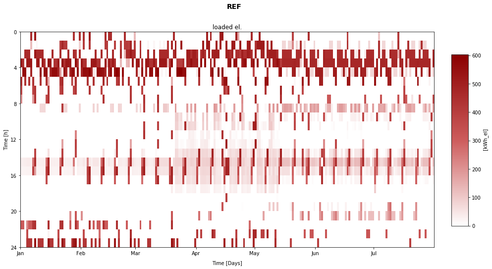

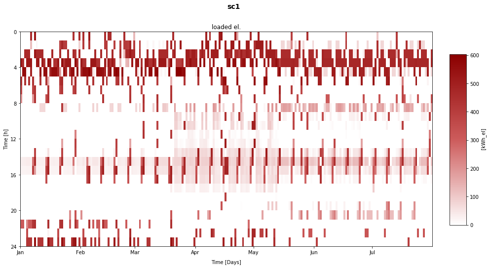

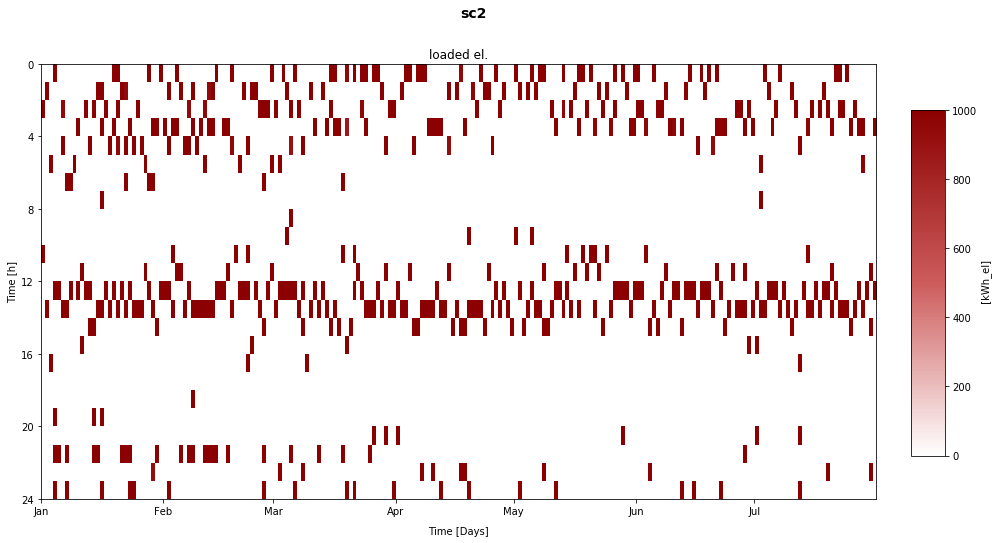

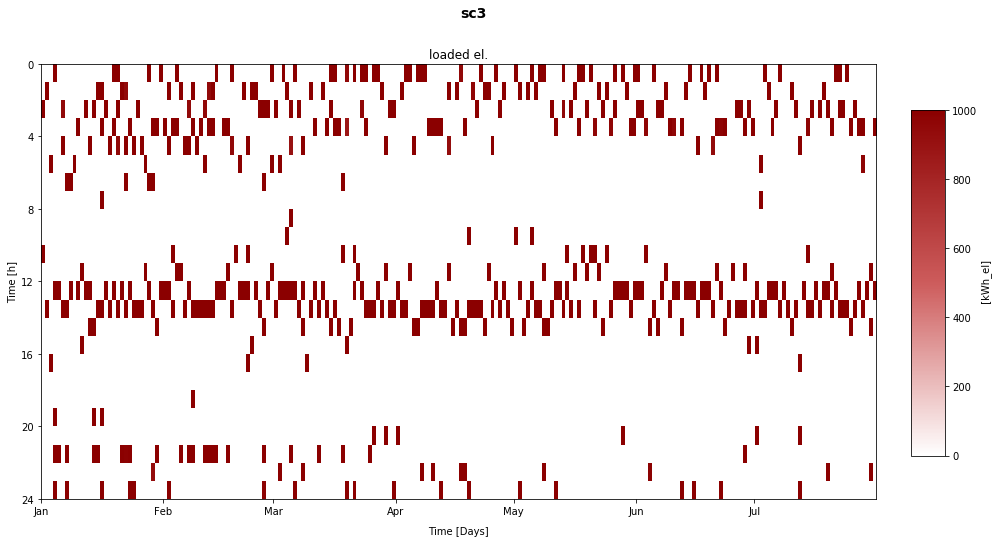

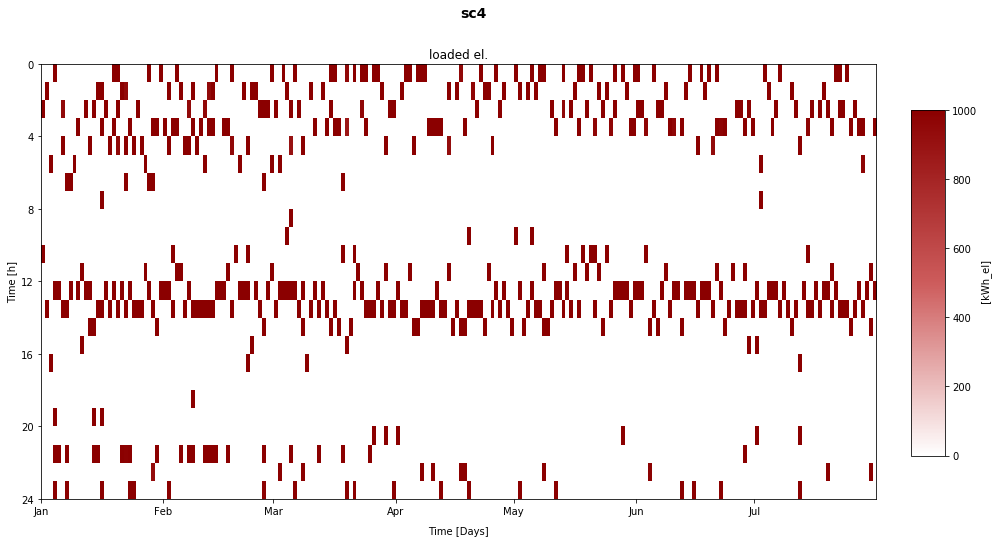

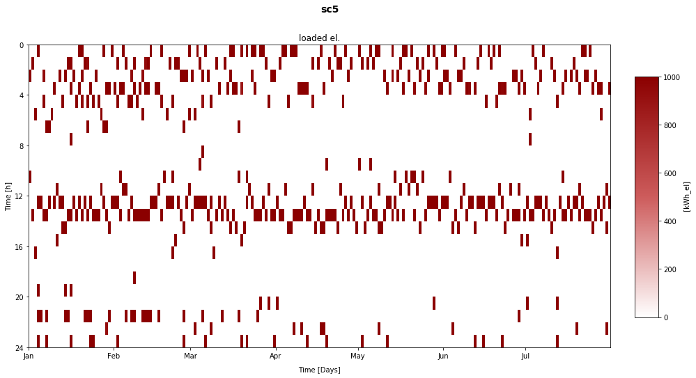

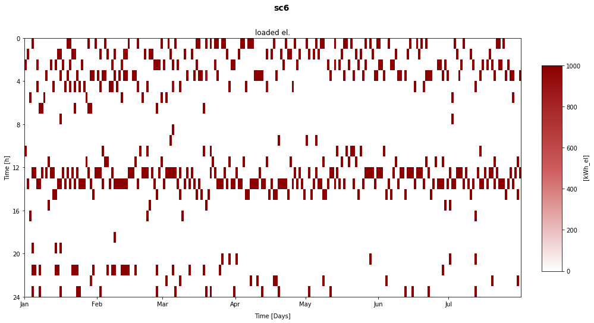

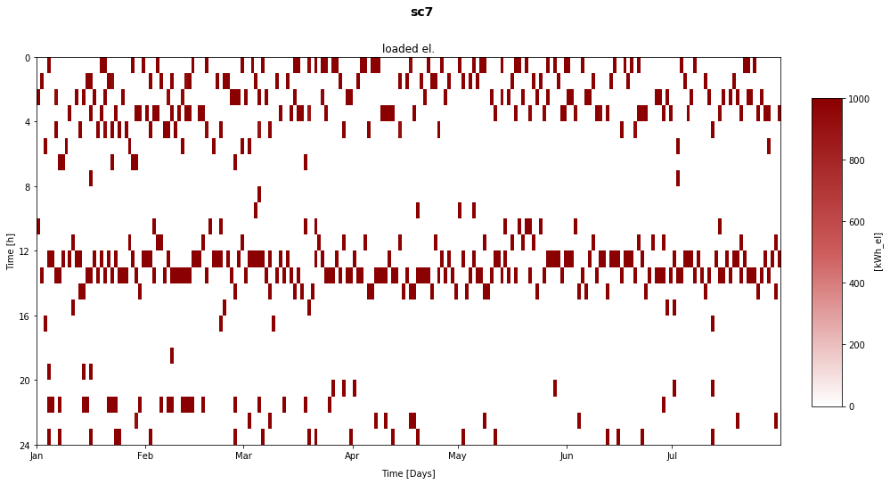

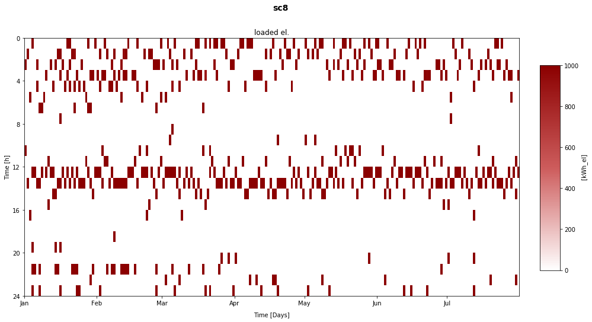

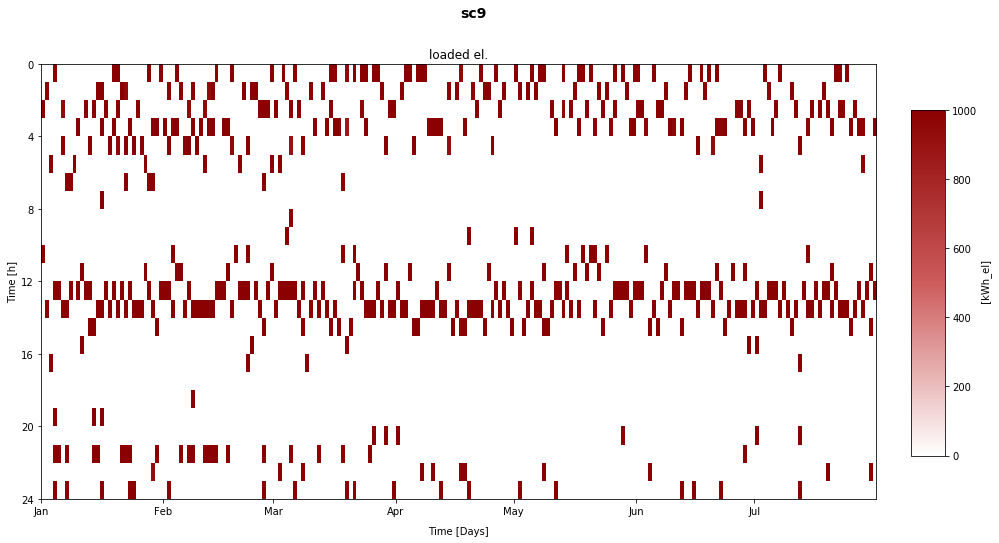

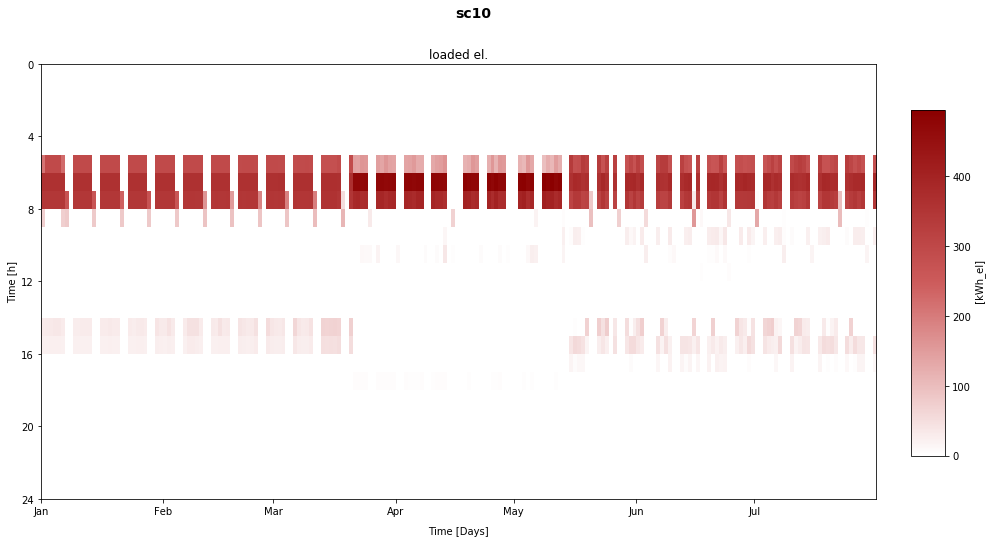

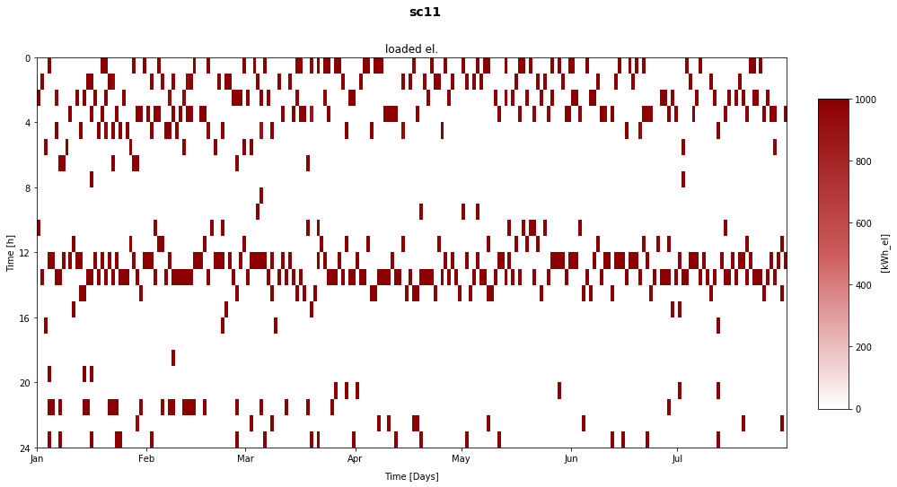

[16 more figures not shown]

```python
for sc in cs.scens_list:
    sc.plot.heatmap(ent_name="E_BES_in_T", suptitle=sc.id, divergingNorm=True);
```